# Cinema Project - Conjoint Analysis

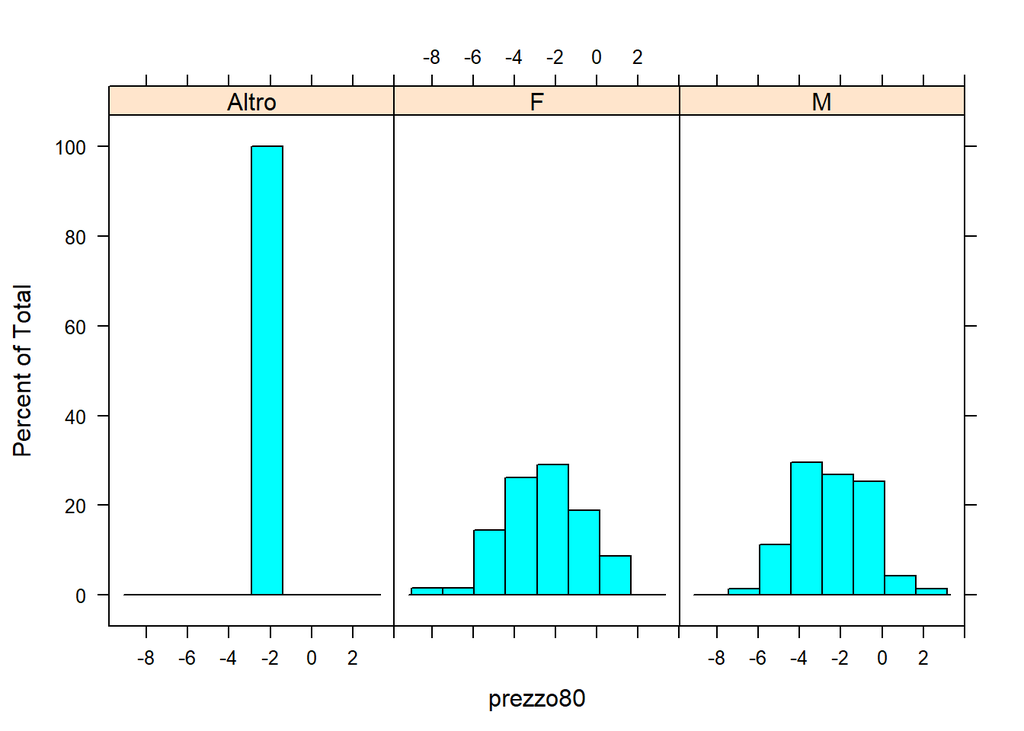

```r
histogram(~ prezzo80 | genere, data=PW.ind)
```

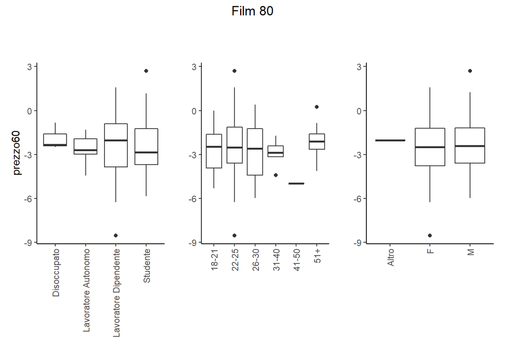

```r
p1 <- ggplot(PW.ind, aes(x=professione, y=prezzo80)) + geom_boxplot() +
  labs(title = "", subtitle = "",
       x = "", y = "prezzo60") +
  theme_classic() +
  theme(plot.title = element_text(hjust = 0.5), # center title
        axis.text.x = element_text(angle = 90, vjust = 0.5, hjust=1),
        text = element_text(family = "sans")) # font

p2 <- ggplot(PW.ind, aes(x=età, y=prezzo80)) + geom_boxplot() +
  labs(title = "", subtitle = "",
       x = "", y = "") +
  theme_classic() +
  theme(plot.title = element_text(hjust = 0.5), # center title
        axis.text.x = element_text(angle = 90, vjust = 0.5, hjust=1),
        text = element_text(family = "sans")) # font

p3 <- ggplot(PW.ind, aes(x=genere, y=prezzo80)) + geom_boxplot() +
  labs(title = "", subtitle = "",
       x = "", y = "") +
  theme_classic() +
  theme(plot.title = element_text(hjust = 0.5), # center title
        axis.text.x = element_text(angle = 90, vjust = 0.5, hjust=1),
        text = element_text(family = "sans")) # font

pp <- p1+p2+p3
pp + plot_annotation(title = 'Film 80', theme = theme(plot.title = element_text(hjust = 0.5)))
```

```r
by(PW.ind$ prezzo80, PW.ind$professione, mean)
```

```
## PW.ind$professione: Disoccupato
## [1] -1.891728
## ------------------------------------------------------------
## PW.ind$professione: Lavoratore Autonomo
## [1] -2.58643
## ------------------------------------------------------------
## PW.ind$professione: Lavoratore Dipendente
## [1] -2.3471
## ------------------------------------------------------------
## PW.ind$professione: Studente
## [1] -2.564071
```

```r
t.test(prezzo80 ~ professione, data=professione_lav_stu)
```

```
##
##  Welch Two Sample t-test
##
## data:  prezzo80 by professione
## t = 0.6203, df = 95.026, p-value = 0.5365
## alternative hypothesis: true difference in means is not equal to 0
## 95 percent confidence interval:
##  -0.4774303  0.9113725
## sample estimates:
## mean in group Lavoratore Dipendente              mean in group Studente
##                           -2.347100                           -2.564071
```

```r
t.test(prezzo80 ~ età, data=età_lav_stu)
```

```
##
##  Welch Two Sample t-test
##
## data:  prezzo80 by età
## t = -0.88758, df = 24.964, p-value = 0.3832
## alternative hypothesis: true difference in means is not equal to 0
## 95 percent confidence interval:
##  -1.2894424  0.5127998
## sample estimates:
## mean in group 18-21 mean in group 22-25
##           -2.697726           -2.309404
```

```r
t.test(prezzo80 ~ genere, data=genere_lav_stu)
```

```
##
##  Welch Two Sample t-test
##
## data:  prezzo80 by genere
## t = -0.52805, df = 135.71, p-value = 0.5983
## alternative hypothesis: true difference in means is not equal to 0
## 95 percent confidence interval:
##  -0.7707621  0.4458947
## sample estimates:
## mean in group F mean in group M
##       -2.559874       -2.397440
```

The little niche found for both the price levels is not explained by these individual variables: the distributions and boxplots do not reveal any particular difference and the t.test confirms this observation.

Overall, from the above analysis we cannot assess that any of the possible niches found were related to the individual variables we got. The cases where it seemed to be a difference were the ones related to the `età`, as for the variable movie type `Animazione`, where we can hypothesize there may be more interest among the `18-21` generation for this kind of movie respect to the others. We could state the same hypothesis for the variable `qual_cine3D`, since the p-value among the two age range was low, but in this case specifically we are quite skeptical about the result given our a-priori beliefs. In our analysis we could not make a t.test among all the difference age ranges, due to lack of observations, but it would probably be a variable of interest with more data. While for the variable `Posizione` there was any significant difference, for the variable `Genere` we almost found it to be significant to express the preference for the `qual_stream4K`.

# 7 Conclusion

This project is based on the research question “Which kind of pass can revive the cinema sector in this pandemic period?”. To answer this question, we analysed the responses to the survey and displayed some interesting results.

A first half of the answer comes from the model that did not consider heterogeneity (m1). Here, we calculated **willingness-to-pay** and **preference shares** to see how different levels of attributes were valued. The analysis shows that the respondents favored *less expensive* cinema passes, held in the *evening (21-24)* and with *commercial movies*. On the other hand, they did **not** give particular weight to the *quality of the video* offered and the *number of films* in the pass, although in the latter it is evident that they preferred cinema passes with more movies available. We have justified the low significance of the variables relating to the quality of the video by saying that it is likely that the respondents have not grasped the benefits of a higher quality, thus considering the other variables as more influential on the final choice. Already from these data we noticed a strange tendency to devalue cinema passes with **3D** movies, an aspect that we investigated while examining the respondents’ heterogeneity.

The next step of the analysis has been studying the heterogeneity present in the different attribute levels. We used the mixed MNL without and with correlations between the variables. As we expected, the effects of heterogeneity were higher in the latter. Since the latter was the model that best modeled our data, we chose it to identify differences in the choices made.

The second half of the answer was found in this part, since we were able to identify attribute levels that might contain consumer niches. In particular, the levels related to *price*, *video quality* and *type of film* attracted our attention. We did not overestimate the variables referred to *independent* movies, with video quality of cinema “*IMAX*” and quality of streaming “*4k*” as they are not significant in the model. On the other hand, the `3D` and `Animation` levels are noteworthy: they present significant and negative coefficients and an interesting level of heterogeneity. From the analysis of the random coefficients, we identify a niche in both of this attribute level. For the level `3D` we are uncertain if this outcome is related to a niche of respondents that actually prefer this cinema feature, or is a niche given by the choices made due to the survey configuration. While for the level `Animation` we can assess there is a small group of respondents that like this movie type.

Given these results we foster a kind of pass that goes towards the needs of the respondents. We have understood that the best average pass according to the single levels is the one that combines a high number of movie, a Commercial type and evening shows. However, it is not the only information that we have extracted. There are some respondents that actually would go to afternoon shows to watch an *indipendent* movie, even though the price is not the lowest and the number of movies is restrained. There is also a small niche of respondents that would love to watch some *animation* movies, they do not want a pass that has a lot of tickets. Quality seems to take second place in overall preference, so a cinema could manage to emphasise film content over high quality in the theater. Then, even if this analysis did not highlight important individual variables, age seems to be an element to be considered in the creation of the pass. Further research could be done to evaluate this association, however we could try to make a suggestion and suggest differentiating passes by age.

[^1]: We transposed the output of R in HTML format and improved the obtained tables using CSS.